# CardioGoodFitness-Mora

#### Preparation

```python
# Import libraries
import pandas as pd
import matplotlib.pyplot as plt
from scipy.stats import skew, norm, probplot, boxcox, f_oneway
import seaborn as sns
import warnings
warnings.filterwarnings("ignore")
from PIL import Image
```

```python
# read provided data file.
# Begin by checking data file size and shape, including the top 5 rows.

data = pd.read_csv('CardioGoodFitness.csv')
print('The number of rows and columns in the source file equals',data.shape)
data.head()
```

```
The number of rows and columns in the source file equals (180, 9)
```

|  | Product | Age | Gender | Education | MaritalStatus | Usage | Fitness | Income | Miles |
| --- | --- | --- | --- | --- | --- | --- | --- | --- | --- |
| 0 | TM195 | 18 | Male | 14 | Single | 3 | 4 | 29562 | 112 |
| 1 | TM195 | 19 | Male | 15 | Single | 2 | 3 | 31836 | 75 |
| 2 | TM195 | 19 | Female | 14 | Partnered | 4 | 3 | 30699 | 66 |
| 3 | TM195 | 19 | Male | 12 | Single | 3 | 3 | 32973 | 85 |
| 4 | TM195 | 20 | Male | 13 | Partnered | 4 | 2 | 35247 | 47 |

```python
# Review the nine column variables, each data type and whether there are any nulls or gaps in the data

data.info()
```

```
<class 'pandas.core.frame.DataFrame'>
RangeIndex: 180 entries, 0 to 179
Data columns (total 9 columns):
 #   Column         Non-Null Count  Dtype
---  ------         --------------  -----
 0   Product        180 non-null    object
 1   Age            180 non-null    int64
 2   Gender         180 non-null    object
 3   Education      180 non-null    int64
 4   MaritalStatus  180 non-null    object
 5   Usage          180 non-null    int64
 6   Fitness        180 non-null    int64
 7   Income         180 non-null    int64
 8   Miles          180 non-null    int64
dtypes: int64(6), object(3)
memory usage: 12.8+ KB
```

```python
# The previous info method indicates there are no missing data but here's another way to investigate
data.isnull().sum()
```

```
Product          0
Age              0
Gender           0
Education        0
MaritalStatus    0
Usage            0
Fitness          0
Income           0
Miles            0
dtype: int64
```

#### Conclusions:

- The data file was successfully read and data appears complete.
- Each row provides a variety of customer attributes by product model.
- The data file provides 180 rows of information organized as nine columns.
  - We can see there are categorical variables: Product, Gender, Marital Status.
  - The remaining variables are numeric data with both discrete and continuous items to analyze
  - Discrete variables: Age,Education, Usage, Fitness
  - Continuous variables: Income, Miles
- Next steps, I will describe relationships between the customers and their product models.

#### Analysis

- Using descriptive statistics first for the entire dataframe.
- Then progressing to study the data supporting each Product model.

```python
# A statistical summary of the data frame
# It may be more valuable to explore statistics including correlation for the data by product model
round(data.describe()) # I have decided to round the data for convenience
```

|  | Age | Education | Usage | Fitness | Income | Miles |
| --- | --- | --- | --- | --- | --- | --- |
| count | 180.0 | 180.0 | 180.0 | 180.0 | 180.0 | 180.0 |
| mean | 29.0 | 16.0 | 3.0 | 3.0 | 53720.0 | 103.0 |
| std | 7.0 | 2.0 | 1.0 | 1.0 | 16507.0 | 52.0 |
| min | 18.0 | 12.0 | 2.0 | 1.0 | 29562.0 | 21.0 |
| 25% | 24.0 | 14.0 | 3.0 | 3.0 | 44059.0 | 66.0 |
| 50% | 26.0 | 16.0 | 3.0 | 3.0 | 50596.0 | 94.0 |
| 75% | 33.0 | 16.0 | 4.0 | 4.0 | 58668.0 | 115.0 |
| max | 50.0 | 21.0 | 7.0 | 5.0 | 104581.0 | 360.0 |

**Evaluate categorical variables**

```python
# Three of the nine series are of type Object.
# First, I want to know how many product models we are dealing with in this data
# I can look at how many times the Product models occur by counting data values

print(data.columns,"\n")
print(data.value_counts("Product"),"\n\n",data.value_counts("Gender"),"\n\n",data.value_counts("MaritalStatus"))
```

```
Index(['Product', 'Age', 'Gender', 'Education', 'MaritalStatus', 'Usage',
       'Fitness', 'Income', 'Miles'],
      dtype='object')

Product
TM195    80
TM498    60
TM798    40
dtype: int64

 Gender
Male      104
Female     76
dtype: int64

 MaritalStatus
Partnered    107
Single        73
dtype: int64
```

**Conclusions:**

- There are 3 product models: TM195, TM498, TM798 occuring 80, 60, 40 times, respectively
- TM195 occurs most frequently and twice that of TM798
- Customers use more TM195 and TM498 models than TM798
- Over half the customers are male. Also, over half of the customers are Partnered.
- I will evaluate the numeric variables by products later.

```python
# Let's take graphical look at categorical variables

labels = data.value_counts("Product") # create summary Product count info for a graph
GenLbl = data.value_counts("Gender").index # and do the same for Gender count
```

```python
GenLbl # labels for a chart
```

```
Index(['Male', 'Female'], dtype='object', name='Gender')
```

```python
labels # labels for a chart
```

```
Product
TM195    80
TM498    60
TM798    40
dtype: int64
```

```python
plt.style.available # check the plot styles available
plt.style.use('seaborn') # select a plot style
```

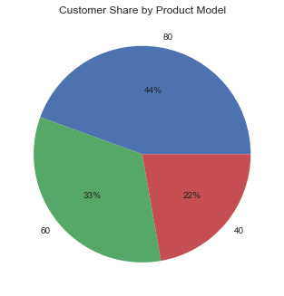

```python
# this pie chart illustrates the share of product in the data

plt.pie(data.value_counts("Product"), radius=1, labels=labels, autopct='%1.0f%%')
plt.title("Customer Share by Product Model") # Include a basic chart title
plt.show() # use this method for more appealing charts
```

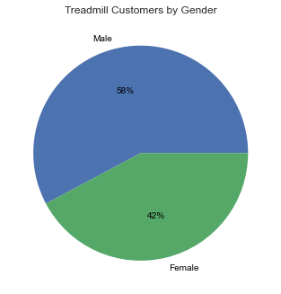

```python
# Next, create a pie chart of male v. female customers

plt.pie(data.value_counts("Gender"), radius=1,autopct='%1.0f%%', labels=GenLbl, textprops=dict(color="black"))
plt.title("Treadmill Customers by Gender")
plt.show()
```

**Fitness levels and Product models**

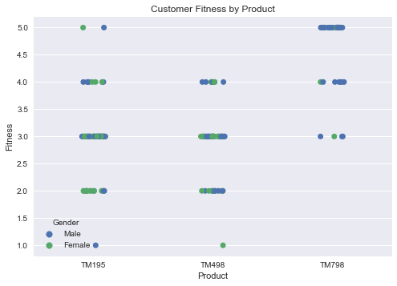

```
Preliminary conclusions:
Customers with above average fitness levels use the TM798 product.
Customers with lower fitness use both the TM195 and TM498.
```

```python
# Use stripplot to organize a basic comparison Fitness levels across Product Models
# Including hue = Gender further helps visualize this comparison

sns.stripplot(x=data.Product, y=data.Fitness, hue=data.Gender, size=7, jitter=True) # high fitness prefers TM798
plt.title("Customer Fitness by Product")
plt.show()

# Add some concluding comments
print('Preliminary conclusions:')
print('Customers with above average fitness levels use the TM798 product.')
print('Customers with lower fitness use both the TM195 and TM498.')
```

**Fitness levels and Income**

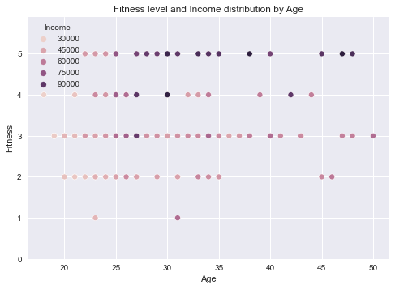

```
Higher fitness and higher income seem to go together, regardless of age
```

```python
# Create a scatterplot of Fitness and Income by Age

sns.scatterplot(x=data.Age, y=data.Fitness, hue=data.Income)
plt.title("Fitness level and Income distribution by Age")
plt.ylim(0,5.9)
plt.show()
print('Higher fitness and higher income seem to go together, regardless of age')
```

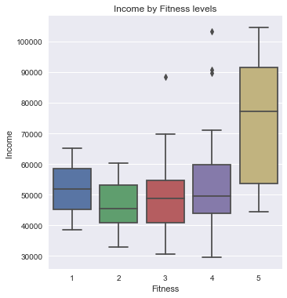

```python
# Utilize a box plot of Income by Fitness level to visualize key differences utilizing catplot method
sns.catplot(x="Fitness", y="Income", data=data, kind="box")
plt.title("Income by Fitness levels")
plt.show()
```

**Conclusion: There is Significantly higher income in the highest fitness category**

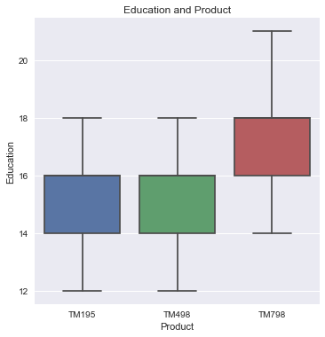

```python
# Create a similar visualization for Education by Product
sns.catplot(y="Education", data=data, x="Product", kind="box")
plt.title("Education and Product")
plt.show()
```

**Conclusion: Education levels are higher for TM798**

```python
# group the data by Product, evaluate the mean absolute deviation (MAD)
# lower numbers indicate minimal deviation
# I am rounding the data for convenience
#groupby helps me look at variables without dropping rows
round(data.groupby(["Product"]).mad())
```

| Product | Age | Education | Usage | Fitness | Income | Miles |
| --- | --- | --- | --- | --- | --- | --- |
| TM195 | 6.0 | 1.0 | 1.0 | 0.0 | 7481.0 | 22.0 |
| TM498 | 6.0 | 1.0 | 1.0 | 0.0 | 6753.0 | 24.0 |
| TM798 | 5.0 | 1.0 | 1.0 | 1.0 | 16510.0 | 44.0 |

**Income and Miles have a larger difference when comparing models**

```python
# group the data by Fitness level, evaluate the mean absolute deviation (MAD)
# repeat for Fitness groupby
round(data.groupby(["Fitness"]).mad())
```

| Fitness | Age | Education | Usage | Income | Miles |
| --- | --- | --- | --- | --- | --- |
| 1 | 4.0 | 1.0 | 0.0 | 13281.0 | 13.0 |
| 2 | 5.0 | 1.0 | 1.0 | 6526.0 | 9.0 |
| 3 | 6.0 | 1.0 | 1.0 | 8010.0 | 14.0 |
| 4 | 5.0 | 1.0 | 1.0 | 13592.0 | 30.0 |
| 5 | 6.0 | 1.0 | 1.0 | 17921.0 | 43.0 |

**Fitness levels comparatively show more deviation at the highest and lowest levels**

```python
# group the data by Fitness level, evaluate the mean
round(data.groupby(["Fitness"]).mean())
```

| Fitness | Age | Education | Usage | Income | Miles |
| --- | --- | --- | --- | --- | --- |
| 1 | 27.0 | 17.0 | 2.0 | 51939.0 | 34.0 |
| 2 | 28.0 | 15.0 | 3.0 | 46180.0 | 52.0 |
| 3 | 29.0 | 15.0 | 3.0 | 48853.0 | 87.0 |
| 4 | 28.0 | 16.0 | 4.0 | 54995.0 | 132.0 |
| 5 | 30.0 | 17.0 | 5.0 | 74397.0 | 179.0 |

Brief conclusions:  
When comparing customers by Fitness Level we find average income is highest for the highest fitness level customers.  
It is also interesting that Customers with high Fitness levels (4, 5), expect to run significantly higher mileage.  
Once customers reach level 3 fitness their usage / week increases

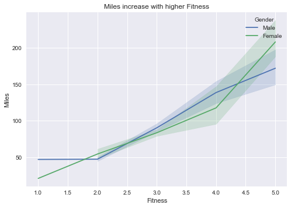

```python
# The miles intended increase with higher fitness
# using a simple line plot will help visualize these two continuous data types
sns.lineplot(x=data.Fitness,y=data.Miles, hue=data.Gender)
plt.title("Miles increase with higher Fitness")
plt.show()
```

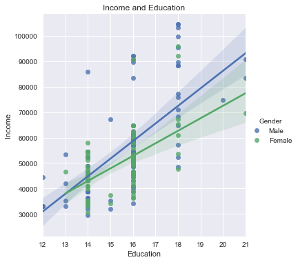

```
incomes for females diverge from their male counterparts as education increases
```

```python
# Income increases with Education, as expected. However, female income increases at a lower rate
# a linear regression plot helps relate Income and Education
sns.lmplot(y="Income", x="Education", data=data, hue="Gender") # linear regression model
plt.title("Income and Education")
plt.show()
print('incomes for females diverge from their male counterparts as education increases')
```

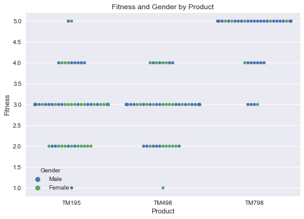

```python
# Fitness comparisons using the swarm plot helps visualize which fitness levels have a higher density
# later I can fix the y-axis to better match the discrete integer nature of fitness level
sns.swarmplot(x=data.Product, y=data.Fitness, hue=data.Gender)
plt.title('Fitness and Gender by Product')
plt.show()
```

**Brief conclusions about the swarm plot:**

```
- Average fitness level customers appear to equally use both TM195 and TM498 models<br>
- While the TM798 has the largest utilization at the highest fitness category<br>
- TM798 has mostly male customers<br>
```

Let's create a violin plot to show the density relationships

```
<function matplotlib.pyplot.show(close=None, block=None)>
```

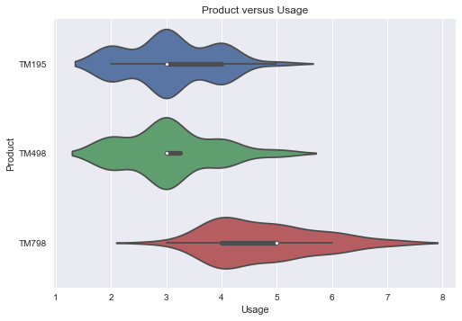

```python
# This violin plot shows the density of Product versus Fitness level
# This is a helpful alternative view to the strip plot above
sns.violinplot(x=data.Usage, y=data.Product)
plt.title("Product versus Usage")
plt.show
```

```
<function matplotlib.pyplot.show(close=None, block=None)>
```

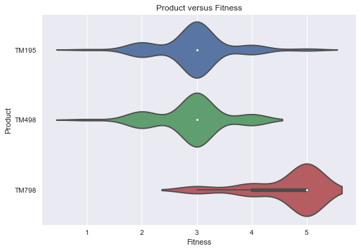

```python
# This violin plot shows the density of Product versus Fitness level
# This supports the strip plot above
sns.violinplot(x=data.Fitness, y=data.Product)
plt.title("Product versus Fitness")
plt.show
```

**Brief conclusions about the violin plot:**

```
- TM798 customers are concentrated around the highest fitness category<br>
- While both TM195 and TM498 customers concentrate around average fitness <br>
```

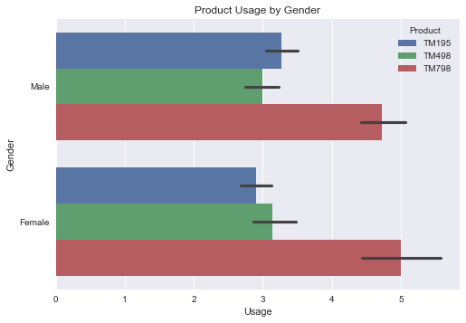

```python
# TM798 customers exercise almost 2 more times per week
# bar plots are simple and easy to understand, and they are helpful when plotting categorical data
sns.barplot(data['Usage'], data['Gender'], hue=data['Product'])
plt.title("Product Usage by Gender")
plt.show()
```

**Conclusions:**

- From earlier chart, TM195 and TM498 products combined represent 77% of the data provided
- Customers more often selected these product models versus the TM798
- However, TM798 customers use their product more times per week than the other customers

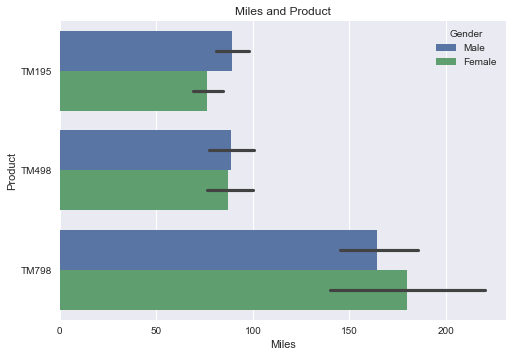

```python
# Not surprisingly, Miles are higher for both Genders when using TM798
sns.barplot(data['Miles'], data['Product'], hue=data['Gender'])
plt.title("Miles and Product")
plt.show()
```

**Conclusions:**

- Both Genders have higher mileage on the TM798
- This is somewhat expected as higher fitness levels and higher miles go together
- From an earlier comparison, we noticed significant differences in genders using each model. next bar graphs..

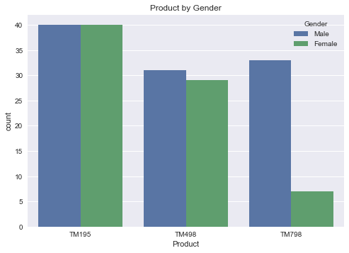

```python
# Genders use TM195 and TM498 almost equally
# Male customers eclipse female customers of TM798
sns.countplot(data['Product'], hue=data['Gender'])
plt.title('Product by Gender')
plt.show()
```

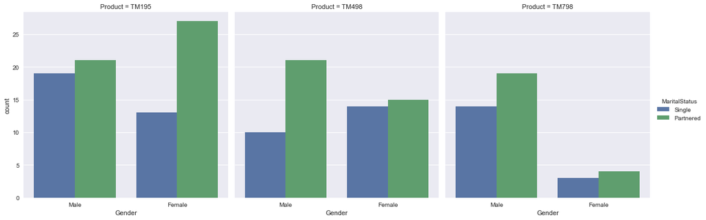

```python
# Visualizing Gender and Marital Status for each Product
sns.catplot(x="Gender", hue="MaritalStatus", col="Product", data=data, kind="count") # count plot

plt.show()
```

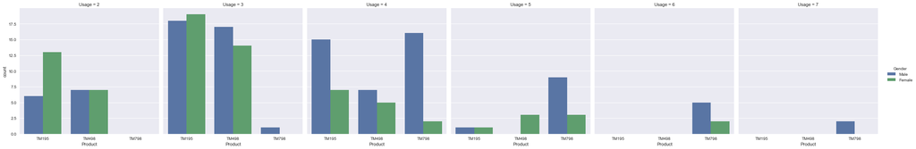

```python
# Usage
sns.catplot(x="Product", hue="Gender", col="Usage", data=data, kind="count") # count plot

plt.show()
```

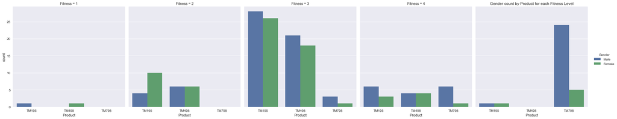

```python
# A summary view of Gender count by Product for each Fitness level
sns.catplot(x="Product", hue="Gender", col="Fitness", data=data, kind="count") # count plot
plt.title("Gender count by Product for each Fitness Level")
plt.show()
# various types of kind: point, bar, count, box, violin, strip
# for count, there is no "y" variable
```

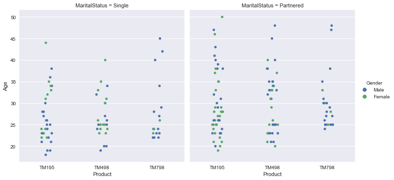

```python
# Now we will take a look at how Married Status relates to Product models used
# I can try this using both hue and col or, eliminating Gender
# the catplot provides the ability to do a multi-variate study
sns.catplot(x="Product", y="Age", hue="Gender", col="MaritalStatus", data=data, kind="strip", jitter=True)
#plt.title("Customer Age, Gender and Marital Status across Product")
plt.show()
# just a minor programming note re types of kind: point, bar, count, box, violin, strip
# for count, there is no "y" variable
```

**Next items,**

- Age univariate analysis using distribution and density
- Correlation and heat map

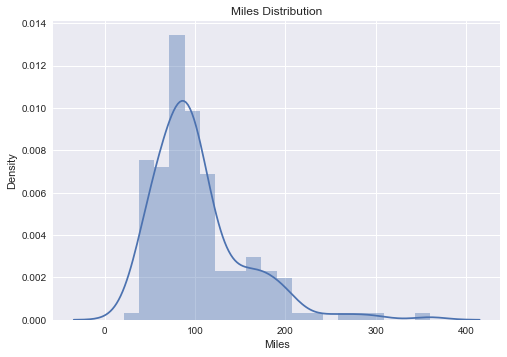

```python
# a useful uni-variate graph is the distribution plot
# for the following several plots, I just want to see the skewness and general distribution
sns.distplot(data['Miles']) # plots a frequency polygon superimposed on a histogram using the seaborn package.
plt.title("Miles Distribution")
plt.show()
```

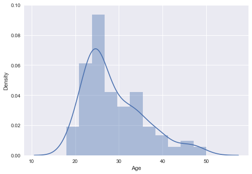

```python
sns.distplot(data['Age']) # plots a frequency polygon superimposed on a histogram using the seaborn package.
plt.ylim(0,0.1)
plt.show()
# seaborn automatically creates class intervals. The number of bins can also be manually set.
```

Both Miles and Age distribution graphs show skewness  
Let's look further for highly skewed (> 0.7) variables in this product category  
Will proceed by re-applying some code snippets from practices exercises

```python
#select numeric features
numerical_features = data.select_dtypes(include=["int64","float64"])
numerical_features.columns
```

```
Index(['Age', 'Education', 'Usage', 'Fitness', 'Income', 'Miles'], dtype='object')
```

Reference note from, https://docs.scipy.org/doc/scipy-0.14.0/reference/generated/scipy.stats.skew.html  
"For normally distributed data, the skewness should be about 0. A skewness value > 0 means that there is more weight in the left tail of the distribution."

```python
#Utilize a lambda function and call to scipy skew to return skew value for the numeric features
skewed_features = numerical_features.apply(lambda x : skew(x.dropna())).sort_values(ascending=False)

#apply the test for highly skewed as > 0.7
skewness=skewed_features[abs(skewed_features)>0.7]
#print the results
print ("There are {} highly skewed numerical features.".format(skewness.shape[0]),"\n",skewness)
```

```
There are 4 highly skewed numerical features.
 Miles     1.710092
Income    1.280995
Age       0.973957
Usage     0.733318
dtype: float64
```

#### Consistent with the visual indication above, for example, Age shows skewness along with Miles, Income and Usage

#### Correlation

- looking at the strength of variable correlation helps surface interesting relationships
- as a rule of thumb, correlation coefficients greater than 0.6 are interesting, whether positive or negative
- a corr coeff of 1.0 is perfect correlation

```python
# Correlation Coefficients are also helpful and here is a tabular view
# I will look at coefficients larger than 0.6 which indicate stronger correlation
# A coefficient of 1.0 indicates perfect correlation as can be see from the diagonals
data.corr()   # displays the correlation between every possible pair of attributes as a dataframe
```

|  | Age | Education | Usage | Fitness | Income | Miles |
| --- | --- | --- | --- | --- | --- | --- |
| Age | 1.000000 | 0.280496 | 0.015064 | 0.061105 | 0.513414 | 0.036618 |
| Education | 0.280496 | 1.000000 | 0.395155 | 0.410581 | 0.625827 | 0.307284 |
| Usage | 0.015064 | 0.395155 | 1.000000 | 0.668606 | 0.519537 | 0.759130 |
| Fitness | 0.061105 | 0.410581 | 0.668606 | 1.000000 | 0.535005 | 0.785702 |
| Income | 0.513414 | 0.625827 | 0.519537 | 0.535005 | 1.000000 | 0.543473 |
| Miles | 0.036618 | 0.307284 | 0.759130 | 0.785702 | 0.543473 | 1.000000 |

**Correlation coefficients represented with a heatmap are easier to visualize.**

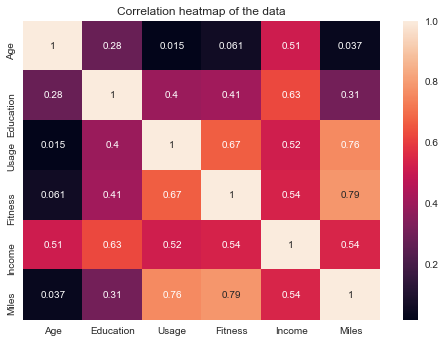

```python
# Heatmap of Correlation Coefficients
sns.heatmap(data.corr(), annot=True)
plt.title('Correlation heatmap of the data')
plt.show()
```

Continuing analysis by Product: TM195, TM498, TM798  
The following approach will be utilized:

```
- Focus product by product basis<br>
- Evaluate summary statistics<br>
- Create charts to visually assess relationships<br>
```

TM195 Analysis

```python
# re-read the data file
data = pd.read_csv('CardioGoodFitness.csv')
```

```python
# set up row index filters for the dataframe to focus on descriptive stats, product by product
indexTM195 = data[data['Product']!="TM195"].index # prepare to drop all but TM195 rows

indexTM498 = data[data['Product']!="TM498"].index # prepare to drop all but TM498 rows

indexTM798 = data[data['Product']!="TM798"].index # prepare to drop all but TM798 rows

#data.drop(indexTM195,inplace=True) # drop all rows where Product != TM195
#data.drop(indexTM498,inplace=True) # drop all rows where Product != TM498
#data.drop(indexTM798,inplace=True) # drop all rows where Product != TM798
```

```python
# Evaluate TM195 summary statistics
data.drop(indexTM195, inplace=True) # we're saving only the TM195 rows
print("TM195 statistics summary table and quartile information")
round(data.describe())
```

```
TM195 statistics summary table and quartile information
```

|  | Age | Education | Usage | Fitness | Income | Miles |
| --- | --- | --- | --- | --- | --- | --- |
| count | 80.0 | 80.0 | 80.0 | 80.0 | 80.0 | 80.0 |
| mean | 29.0 | 15.0 | 3.0 | 3.0 | 46418.0 | 83.0 |
| std | 7.0 | 1.0 | 1.0 | 1.0 | 9076.0 | 29.0 |
| min | 18.0 | 12.0 | 2.0 | 1.0 | 29562.0 | 38.0 |
| 25% | 23.0 | 14.0 | 3.0 | 3.0 | 38658.0 | 66.0 |
| 50% | 26.0 | 16.0 | 3.0 | 3.0 | 46617.0 | 85.0 |
| 75% | 33.0 | 16.0 | 4.0 | 3.0 | 53439.0 | 94.0 |
| max | 50.0 | 18.0 | 5.0 | 5.0 | 68220.0 | 188.0 |

```python
# Print the Mean Absolute Deviation
print(data.mad())
```

```
Age             5.762500
Education       1.086563
Usage           0.597500
Fitness         0.385938
Income       7480.749375
Miles          21.573125
dtype: float64
```

```python
print("TM195 dataframe information")
print(" ")
data.info()
```

```
TM195 dataframe information

<class 'pandas.core.frame.DataFrame'>
Int64Index: 80 entries, 0 to 79
Data columns (total 9 columns):
 #   Column         Non-Null Count  Dtype
---  ------         --------------  -----
 0   Product        80 non-null     object
 1   Age            80 non-null     int64
 2   Gender         80 non-null     object
 3   Education      80 non-null     int64
 4   MaritalStatus  80 non-null     object
 5   Usage          80 non-null     int64
 6   Fitness        80 non-null     int64
 7   Income         80 non-null     int64
 8   Miles          80 non-null     int64
dtypes: int64(6), object(3)
memory usage: 6.2+ KB
```

```python
print(data.value_counts("Product"),"\n\n",data.value_counts("Gender"),"\n\n",data.value_counts("MaritalStatus"))
```

```
Product
TM195    80
dtype: int64

 Gender
Female    40
Male      40
dtype: int64

 MaritalStatus
Partnered    48
Single       32
dtype: int64
```

Brief summary: The TM195 users have the highest population in the data set, 80  
Gender is split equally  
Over half the customers are partnered

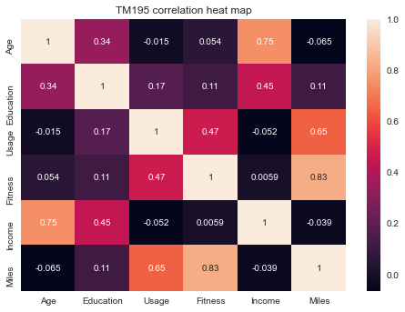

```python
# Identify the strength of correlations with coefficients > 0.60
sns.heatmap(data.corr(), annot=True)  # plot the correlation coefficients as a heatmap
plt.title("TM195 correlation heat map")
plt.show()
```

**TM195 Correlation Summary:**

- Age and Income, positively
- Usage and Miles, positively
- Fitness and Miles, positively

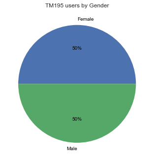

```python
GenLbl = data.value_counts("Gender").index

# create a pie chart of male v. female customers

plt.pie(data.value_counts("Gender"), radius=1,autopct='%1.0f%%', labels=GenLbl, textprops=dict(color="black"))
plt.title("TM195 users by Gender")
plt.show()
```

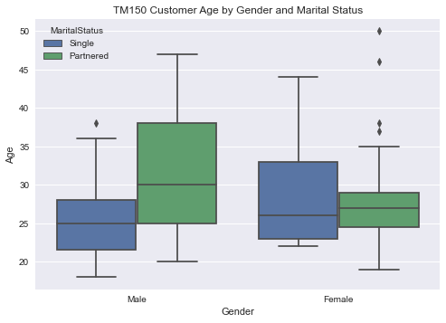

```python
# Look at Age distributions by Gender and Marital Status
sns.boxplot(data['Gender'], data['Age'], hue=data['MaritalStatus']) #, hue=data['Usage'])
plt.title("TM150 Customer Age by Gender and Marital Status")
plt.show()
#print('Partnered customers have a higher median age than single customers, regardless of gender')
```

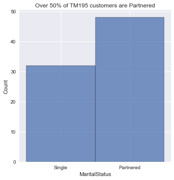

```python
sns.displot(data['MaritalStatus'])
plt.title("Over 50% of TM195 customers are Partnered")
plt.show()
```

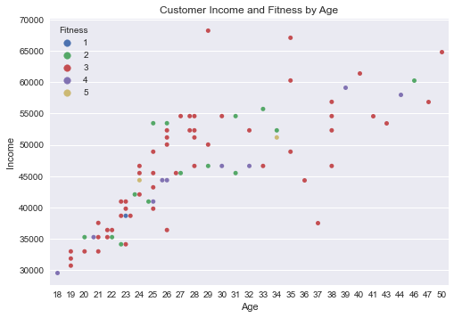

```python
# Look at Income and Fitness level by Age of customer
sns.swarmplot( data['Age'], data['Income'], hue=data['Fitness'])
plt.title("Customer Income and Fitness by Age")
plt.show()
# Generally, income increases with Age
```

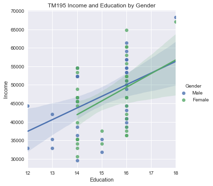

```python
# Use a linear regression plot to assess Income as a function of Education
sns.lmplot(y="Income", x="Education", data=data, hue="Gender") # linear regression model
plt.title("TM195 Income and Education by Gender")
plt.show()
# Generally, income increases with Education
```

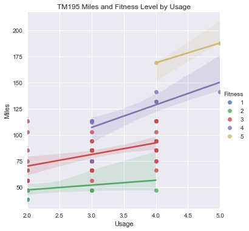

```python
sns.lmplot(x="Usage", y="Miles", data=data, hue="Fitness")
plt.title("TM195 Miles and Fitness Level by Usage")
plt.show()
# higher miles with higher fitness levels
```

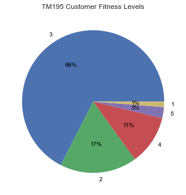

```python
# create a pie chart of male v. female customers
# use pandas value counts method
Lbl = data.value_counts("Fitness").index
plt.pie(data.value_counts("Fitness"), radius=1,autopct='%1.0f%%', labels=Lbl, textprops=dict(color="black"))
plt.title("TM195 Customer Fitness Levels")
plt.show()
```

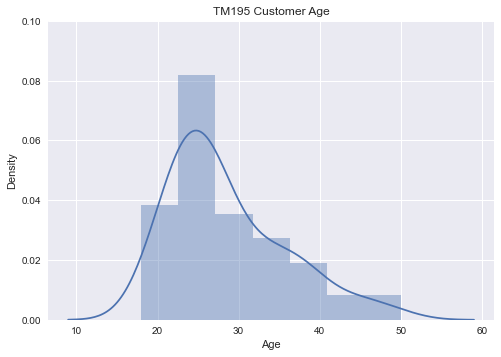

```python
sns.distplot(data['Age'])
plt.title("TM195 Customer Age")
plt.ylim(0,0.1)
plt.show()
```

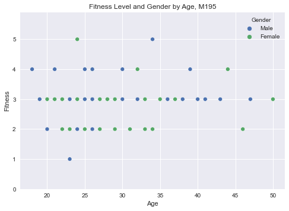

```python
sns.scatterplot(x=data.Age, y=data.Fitness, hue=data.Gender,)
plt.title("Fitness Level and Gender by Age, M195")
plt.ylim(0,5.9)
plt.show()
```

**TM195 conclusions**

```
- Gender use is split 50/50 and over 50% are partnered<br>
- 68% customers report average fitness level 3<br>
- Age distribution is right skewed with median age of 26 years<br>
- Strong positive correlations between Age and Income, and Miles and Fitness Level
```